# Figure 4: Large deletions and genomic integrations

E. coli ORBIT 2023

Scott H. Saunders

# Notes

This figure contains several datatypes from experiments where ORBIT was used for large genomic deletions and integrations. Data figures were made in R notebooks and exported as pdfs. Cosmetic improvements were made in Adobe Illustrator. Note that Figures 4A, 4D & 4F were made in Adobe Illustrator.

Setup packages and plotting for the notebook:

```r
# Check packages
source("../tools/package_setup.R")
# Load packages
library(tidyverse)
library(cowplot)
library(kableExtra)
# Code display options
knitr::opts_chunk$set(tidy.opts=list(width.cutoff=60),tidy=FALSE, echo = TRUE, message=FALSE, warning=FALSE, fig.align="center", fig.retina = 2)
# Load plotting tools
source("../tools/plotting_tools.R")
#Modify the plot theme
theme_set(theme_notebook())
```

# Fig. 4B - Deletion size efficiency

The galK deletions were done separately from the other loci, so let’s read that data in first.

```r
df_gal_sizes <- read_csv('../../data/low_throughput_experiments/2022_11_09_galK_sizes_3_efficiency.csv') %>% #read in csv
  mutate(eff = Kan_count / LB_count) %>% group_by(del_size) %>% mutate(avg_eff = mean(eff)) #calculate efficiency and average efficiency for replicates

#calculate negative control value from galK experiment
gal_sizes_pInt <- (df_gal_sizes %>% filter(del_size == '-'))$avg_eff[1]

df_gal_sizes %>% kable() %>% kable_styling() %>% scroll_box(height = '250px')
```

locus

del_size

replicate

LB_count

Kan_count

eff

avg_eff

galK

1122

1

13900000

33000

0.0023741

0.0026285

galK

1122

2

11100000

32000

0.0028829

0.0026285

galK

4258

1

10800000

1230

0.0001139

0.0001266

galK

4258

2

9900000

1380

0.0001394

0.0001266

galK

10762

1

9400000

430

0.0000457

0.0000592

galK

10762

2

9500000

690

0.0000726

0.0000592

galK

24027

1

10600000

990

0.0000934

0.0000920

galK

24027

2

11700000

1060

0.0000906

0.0000920

galK

49068

1

11400000

160

0.0000140

0.0000164

galK

49068

2

15000000

280

0.0000187

0.0000164

galK

1

11900000

240

0.0000202

0.0000243

galK

2

8800000

250

0.0000284

0.0000243

Now we will read in the data for the other loci (hisA, metA, and leuD).

```r
df_aa_sizes <- read_csv('../../data/low_throughput_experiments/2022_09_07_AA_del_sizes_eff.csv') %>% #read in csv
  mutate(eff = Kan_count / LB_count) %>% group_by(locus, del_size) %>% mutate(avg_eff = mean(eff)) #calculate efficiency and average efficiency for replicates

df_aa_sizes %>% kable() %>% kable_styling() %>% scroll_box(height = '250px')
```

| locus | del_size | replicate | LB_count | Kan_count | eff | avg_eff |
| --- | --- | --- | --- | --- | --- | --- |
| hisA | 100 | 1 | 370000 | 1120 | 0.0030270 | 0.0024635 |
| hisA | 100 | 2 | 900000 | 1710 | 0.0019000 | 0.0024635 |
| hisA | 700 | 1 | 800000 | 5100 | 0.0063750 | 0.0061420 |
| hisA | 700 | 2 | 880000 | 5200 | 0.0059091 | 0.0061420 |
| hisA | 7000 | 1 | 780000 | 100 | 0.0001282 | 0.0001195 |
| hisA | 7000 | 2 | 830000 | 92 | 0.0001108 | 0.0001195 |
| metA | 100 | 1 | 780000 | 8400 | 0.0107692 | 0.0102826 |
| metA | 100 | 2 | 980000 | 9600 | 0.0097959 | 0.0102826 |
| metA | 900 | 1 | 1250000 | 6000 | 0.0048000 | 0.0044886 |
| metA | 900 | 2 | 790000 | 3300 | 0.0041772 | 0.0044886 |
| metA | 13000 | 1 | 890000 | 1010 | 0.0011348 | 0.0010500 |
| metA | 13000 | 2 | 860000 | 830 | 0.0009651 | 0.0010500 |
| leuD | 100 | 1 | 880000 | 1370 | 0.0015568 | 0.0014955 |
| leuD | 100 | 2 | 760000 | 1090 | 0.0014342 | 0.0014955 |
| leuD | 600 | 1 | 1010000 | 720 | 0.0007129 | 0.0005181 |
| leuD | 600 | 2 | 990000 | 320 | 0.0003232 | 0.0005181 |
| leuD | 6000 | 1 | 760000 | 430 | 0.0005658 | 0.0005980 |
| leuD | 6000 | 2 | 730000 | 460 | 0.0006301 | 0.0005980 |
| galK | 1000 | 1 | 700000 | 3600 | 0.0051429 | 0.0039413 |
| galK | 1000 | 2 | 730000 | 2000 | 0.0027397 | 0.0039413 |

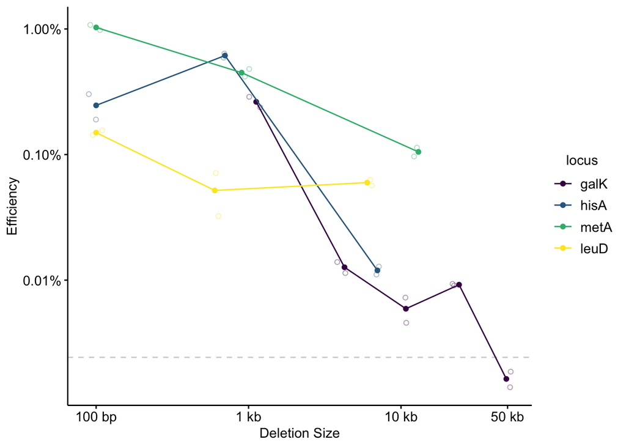

```r
#combine datasets
df_gal_aa_sizes <- bind_rows(df_gal_sizes %>% filter(del_size!='-') %>% mutate(del_size = as.numeric(del_size)),
                             df_aa_sizes %>% filter(locus!='galK')
                             ) %>%
  mutate(locus = factor(locus, levels = c( 'galK','hisA','metA','leuD')))

#Plot with individual datapoints, and mean points connected by lines
plot_gal_aa_sizes <- ggplot(df_gal_aa_sizes, aes(x = del_size, y = eff, color = locus)) +
  geom_hline(yintercept = gal_sizes_pInt, linetype = 2, color = 'light gray')+
  geom_jitter(shape = 21, width = 0.05, height = 0, alpha = 0.4) +
  geom_point(data = . %>% filter(replicate==1), aes(y = avg_eff)) +
  geom_line(data = . %>% filter(replicate==1), aes(y = avg_eff)) +
  scale_y_log10(labels = scales::label_percent(accuracy = 0.01)) +
  scale_x_log10(breaks = c(100, 1000, 10000, 50000), labels = c('100 bp', '1 kb', '10 kb', '50 kb'))+
  labs(y = 'Efficiency', x = 'Deletion Size')+
  scale_color_viridis_d()

plot_gal_aa_sizes
```

# Fig. 4C - Deletion size accuracy

Again galK was done separately from the other loci, so let’s read in that data first:

```r
df_galK_pin <- read_csv("../../data/low_throughput_experiments/2022_11_09_galK_sizes_3_accuracy.csv") %>%
  mutate(accuracy = 1-(selective_colonies / permissive_colonies)) %>%
  group_by(locus, deletion_size) %>%
  mutate(avg_accuracy = mean(accuracy))

df_galK_pin
```

```
## # A tibble: 12 × 9
## # Groups:   locus, deletion_size [6]
##    condition locus deletion_size pInt_…¹ repli…² permi…³ selec…⁴ accur…⁵ avg_a…⁶
##    <chr>     <chr> <chr>         <lgl>     <dbl>   <dbl>   <dbl>   <dbl>   <dbl>
##  1 galK_1kb  galK  1122          FALSE         1       8       0   1      1
##  2 galK_1kb  galK  1122          FALSE         2       8       0   1      1
##  3 galK_4kb  galK  4258          FALSE         1       8       0   1      0.938
##  4 galK_4kb  galK  4258          FALSE         2       8       1   0.875  0.938
##  5 galK_10kb galK  10762         FALSE         1       8       1   0.875  0.875
##  6 galK_10kb galK  10762         FALSE         2       8       1   0.875  0.875
##  7 galK_24kb galK  24027         FALSE         1       8       0   1      1
##  8 galK_24kb galK  24027         FALSE         2       8       0   1      1
##  9 galK_49kb galK  49068         FALSE         1       8       1   0.875  0.875
## 10 galK_49kb galK  49068         FALSE         2       8       1   0.875  0.875
## 11 pInt_only galK  -             TRUE          1       8       8   0      0.0625
## 12 pInt_only galK  -             TRUE          2       8       7   0.125  0.0625
## # … with abbreviated variable names ¹pInt_only, ²replicate,
## #   ³permissive_colonies, ⁴selective_colonies, ⁵accuracy, ⁶avg_accuracy
```

Then we will read in the data for hisA, metA and leuD:

```r
df_aa_pin <- read_csv("../../data/low_throughput_experiments/2022_09_07_AA_sizes_pin_plate_count.csv") %>%
  mutate(accuracy = 1-(selective_colonies / permissive_colonies)) %>%
  group_by(locus, deletion_size) %>%
  mutate(avg_accuracy = mean(accuracy)) %>%
  mutate(locus = factor(locus, levels = c('hisA','metA','leuD')))

df_aa_pin
```

```
## # A tibble: 18 × 9
## # Groups:   locus, deletion_size [9]
##    condition       locus delet…¹ pInt_…² repli…³ permi…⁴ selec…⁵ accur…⁶ avg_a…⁷
##    <chr>           <fct>   <dbl> <lgl>     <dbl>   <dbl>   <dbl>   <dbl>   <dbl>
##  1 hisA 100 bp del hisA      100 FALSE         1       7       0   1       1
##  2 hisA 100 bp del hisA      100 FALSE         2       7       0   1       1
##  3 hisA 700 bp del hisA      700 FALSE         1       7       0   1       1
##  4 hisA 700 bp del hisA      700 FALSE         2       7       0   1       1
##  5 hisA 7000 bp d… hisA     7000 FALSE         1       7       0   1       0.929
##  6 hisA 7000 bp d… hisA     7000 FALSE         2       7       1   0.857   0.929
##  7 metA 100 bp del metA      100 FALSE         1       6       0   1       1
##  8 metA 100 bp del metA      100 FALSE         2       6       0   1       1
##  9 metA 900 bp del metA      900 FALSE         1       7       0   1       1
## 10 metA 900 bp del metA      900 FALSE         2       6       0   1       1
## 11 metA 13000 bp … metA    13000 FALSE         1       7       0   1       1
## 12 metA 13000 bp … metA    13000 FALSE         2       7       0   1       1
## 13 leuD 100 bp del leuD      100 FALSE         1       7       0   1       1
## 14 leuD 100 bp del leuD      100 FALSE         2       6       0   1       1
## 15 leuD 600 bp del leuD      600 FALSE         1       7       0   1       0.929
## 16 leuD 600 bp del leuD      600 FALSE         2       7       1   0.857   0.929
## 17 leuD 6000 bp d… leuD     6000 FALSE         1       7       0   1       0.929
## 18 leuD 6000 bp d… leuD     6000 FALSE         2       7       1   0.857   0.929
## # … with abbreviated variable names ¹deletion_size, ²pInt_only, ³replicate,
## #   ⁴permissive_colonies, ⁵selective_colonies, ⁶accuracy, ⁷avg_accuracy
```

We will combine the data and plot:

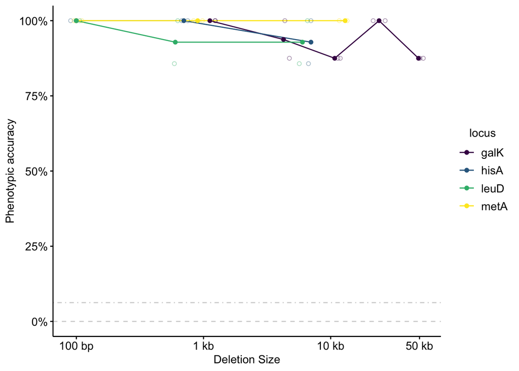

```r
#Combine data
df_galK_aa_pin <- bind_rows(df_galK_pin %>% filter(condition != 'pInt_only') %>% mutate(deletion_size = as.numeric(deletion_size)), df_aa_pin)

#Get background values
galK_bg <- (df_galK_pin %>% filter(condition == 'pInt_only' & replicate == 1))$avg_accuracy

#Plot with individual datapoints, and mean points connected by lines
plot_del_accuracy <- ggplot(df_galK_aa_pin, aes(x = deletion_size, y = accuracy, color = locus)) +
  geom_hline(yintercept = 0, linetype = 2, color = 'light gray')+ #background accuracy for AA loci was 0.
    geom_hline(yintercept = galK_bg, linetype = 4, color = 'light gray')+ #background accuracy for galK is shown separately here.
  geom_line(data = . %>% filter(replicate==1), aes(y = avg_accuracy)) +
  geom_jitter(shape = 21, width = 0.05, height = 0, alpha = 0.4) +
  geom_point(data = . %>% filter(replicate==1), aes(y = avg_accuracy)) +
  scale_y_continuous(labels = scales::label_percent(accuracy = 1), limits = c(0,1)) +
  scale_x_log10(breaks = c(100, 1000, 10000, 50000), labels = c('100 bp', '1 kb', '10 kb', '50 kb'))+
  labs(y = 'Phenotypic accuracy', x = 'Deletion Size')+
  scale_color_viridis_d()

plot_del_accuracy
```

# Fig. 4E - Integrating plasmid size efficiency (violacein operon)

For this experiment different sized fragments from the luxR inducible violacein operon were cloned into an integrating plasmid. Efficiency was measured for each plasmid with the ∆galK TO. Let’s read in the data:

```r
df_vio <- read_csv("../../data/low_throughput_experiments/2022_10_25_pInt_vio_sizes.csv") %>%
  mutate(eff = Kan_count / LB_count) %>%
  group_by(condition, to, plasmid_size) %>% mutate(avg_eff = mean(eff)) #calculate efficiency and average efficiency for replicates

df_vio %>% kable() %>% kable_styling() %>% scroll_box(height = '250px')
```

| condition | to | plasmid_size | replicate | LB_count | Kan_count | eff | avg_eff |
| --- | --- | --- | --- | --- | --- | --- | --- |
| p265 + pInt_kan | 265 | 1958 | 1 | 1140000 | 490 | 0.0004298 | 0.0004158 |
| p265 + pInt_kan | 265 | 1958 | 2 | 1120000 | 450 | 0.0004018 | 0.0004158 |
| p265 + pInt_vioA | 265 | 3628 | 1 | 1080000 | 590 | 0.0005463 | 0.0005694 |
| p265 + pInt_vioA | 265 | 3628 | 2 | 1080000 | 640 | 0.0005926 | 0.0005694 |
| p265 + pInt_vioAB | 265 | 6718 | 1 | 1120000 | 360 | 0.0003214 | 0.0002468 |
| p265 + pInt_vioAB | 265 | 6718 | 2 | 1220000 | 210 | 0.0001721 | 0.0002468 |
| p265 + pInt_vioABC | 265 | 8203 | 1 | 1210000 | 53 | 0.0000438 | 0.0000418 |
| p265 + pInt_vioABC | 265 | 8203 | 2 | 1280000 | 51 | 0.0000398 | 0.0000418 |
| pInt_vioABC only | control | 8203 | 1 | 1040000 | 2 | 0.0000019 | 0.0000019 |
| p265 + pInt_luxR_vioAE | 265 | 10671 | 1 | 1290000 | 32 | 0.0000248 | 0.0000230 |
| p265 + pInt_luxR_vioAE | 265 | 10671 | 2 | 1130000 | 24 | 0.0000212 | 0.0000230 |
| pInt_luxR_vioAE only | control | 10671 | 1 | 1400000 | 0 | 0.0000000 | 0.0000000 |

Now let’s plot:

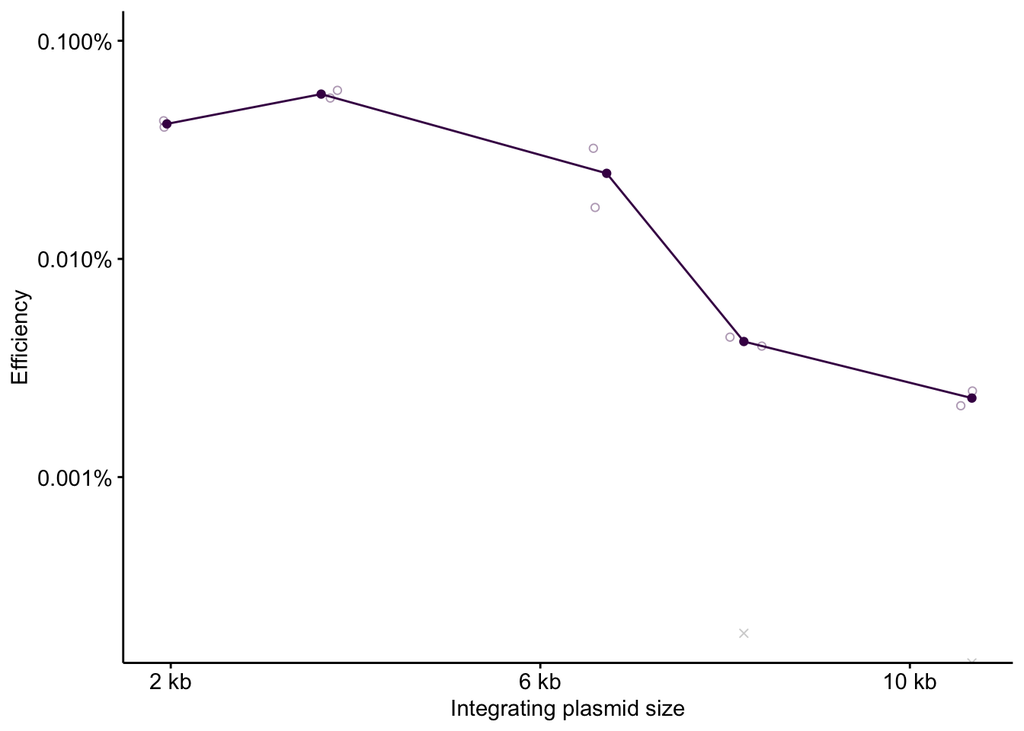

```r
plot_vio <- ggplot(df_vio%>% filter(to != 'control'), aes(x = plasmid_size, y = eff)) +
  geom_jitter(shape = 21, width = 200, height = 0, color = "#440154FF", alpha = 0.4) +
  geom_jitter(data = df_vio %>% filter(to == 'control'), shape = 4, width = 0, height = 0, color = 'light gray') + #negative control efficiencies for pInt_vioA-C and pInt_luxR_vioA-E are shown here
  geom_point(data = . %>% filter(replicate ==1), aes(y = avg_eff), color = "#440154FF") +
  geom_line(data = . %>% filter(replicate ==1), aes(y = avg_eff, group = to), color = "#440154FF") +
  scale_y_log10(limits = c(NA,0.001), labels = scales::label_percent(accuracy = 0.001))+
  scale_x_continuous(breaks = c(2000, 6000, 10000), labels = c('2 kb', '6 kb', '10 kb'))+
  labs(x = 'Integrating plasmid size', y = 'Efficiency')

plot_vio
```

# Create Fig. 4

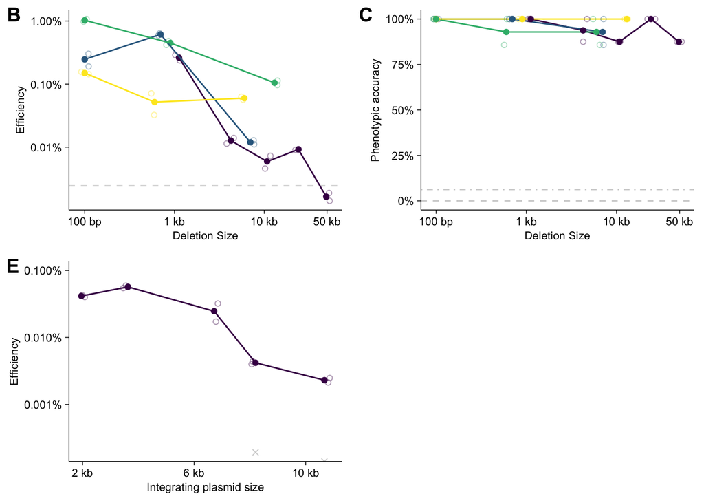

```r
theme_set(theme_figure())

fig_4_sizes <- plot_grid(plot_gal_aa_sizes + guides(color = 'none'), plot_vio, nrow = 1,
                   align = 'hv', axis = 'lr', scale = 1,
                   labels = c('B','E'))

fig_4_sizes <- plot_grid(plot_gal_aa_sizes + guides(color = 'none'),plot_del_accuracy + guides(color = 'none'),
                         plot_vio,NULL,
                         nrow = 2, ncol = 2,
                   align = 'hv', axis = 'lr', scale = 1,
                   labels = c('B','C','E'))

fig_4_sizes
```

```r
save_plot("../../figures/r_pdf_figs/main_figs/fig_4_del_int_sizes.pdf", fig_4_sizes, base_width = 5, base_height = 4)
```